# Análisis de Datos I Tarea 10

# Librerías

```r
library(traineR)
library(caret)
library(dplyr)
library(GGally)
```

# Ejercicio 1

**1. Usando la columna BuenPagador en donde aparece el verdadero valor de la variable a predecir y la columna PrediccionKNN en donde aparece la predicción del Método KNN para esta tabla de Testing, calcule la Matriz de Confusión.**

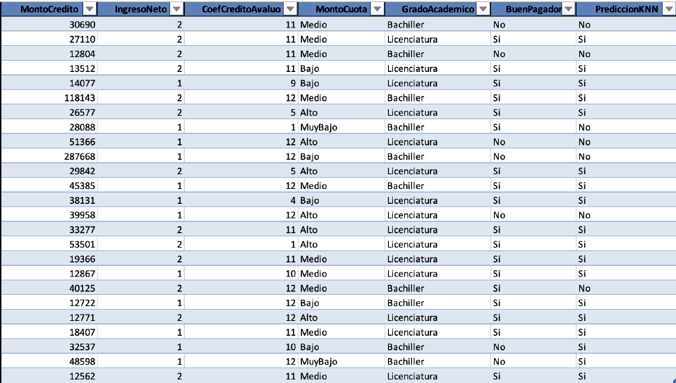

Primeramente, se tienen los siguientes conteos:

```
• Cantidad de verdaderos positivos (VP) : 16
• Cantidad de verdaderos negativos (VN) : 5
• Cantidad de falsos positivos (FP) : 2
• Cantidad de falsos negativos (FN) : 2
```

De tal manera, la matriz de confusión es:

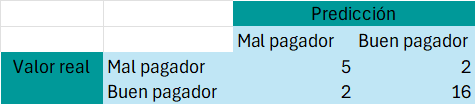

**2. Con la Matriz de Confusión anterior calcule “a mano” la Precisión Global, el Error Global, la Precisión Positiva (PP), la Precisión Negativa (PN), la Proporción de Falsos Positivos (PFP), la Proporción de Falsos Negativos (PFN), la Asertividad Positiva (AP) y la Asertividad Negativa (AN).**

*Precisión Global:*

$P=\dfrac{VP+VN}{VN+FP+FN+VP}=\dfrac{16+5}{5+2+2+16}= \dfrac{21}{25}$

*Error Global:*

$E= \dfrac{FP+FN}{VN+FP+FN+VP}=\dfrac{2+2}{5+2+2+16}= \dfrac{4}{25}$

*Precisión positiva:*

$PP=\dfrac{VP}{FN+VP}=\dfrac{16}{2+16}= \dfrac{8}{9}$

*Precisión negativa:*

$PN=\dfrac{VN}{FP+VN}=\dfrac{5}{2+5}= \dfrac{5}{7}$

*Falsos positivos:*

$PFP= \dfrac{FP}{FP+VN}=\dfrac{2}{2+5}= \dfrac{2}{7}$

*Falsos negativos:*

$PFN=\dfrac{FN}{FN+VP}=\dfrac{2}{2+16}= \dfrac{1}{9}$

*Asertividad Positiva:*

$AP=\dfrac{VP}{FP+VP}=\dfrac{16}{2+16}= \dfrac{8}{9}$

*Asertividad Negativa:*

$AN=\dfrac{VN}{FN+VN}=\dfrac{5}{2+5}= \dfrac{5}{7}$

# Ejercicio 2

- **Con ayuda de la clase programada anteriormente calcule la Precisión Global, el Error Global, la Precisión Positiva (PP), la Precisión Negativa (PN), la Proporción de Falsos Positivos (PFP), la Proporción de Falsos Negativos (PFN), la Asertividad Positiva (AP) y la Asertividad Negativa (AN).**

```r
indices_matriz <- function(matriz_confusion){
  VN <- matriz_confusion[1,1]
  FP <- matriz_confusion[1,2]
  FN <- matriz_confusion[2,1]
  VP <- matriz_confusion[2,2]

  P <- (VN+VP)/sum(matriz_confusion)
  E <- (FP+FN)/sum(matriz_confusion)
  PP <- VP/(FN+VP)
  PN <- VN/(VN+FP)
  PFP <- FP/(VN+FP)
  PFN <- FN/(FN+VP)
  AP <- VP/(FP+VP)
  AN <- VN/(VN+FN)

  indices <- list(
    'Precision Global' = P,
    'Error Global' = E,
    'Precisión Positiva' = PP,
    'Precisión Negativa' = PN,
    'Proporción de Falsos Positivos' = PFP,
    'Proporción de Falsos Negativos' = PFN,
    'Asertividad Positiva' = AP,
    'Asertividad Negativa' = AN
  )

  return(indices)
}
```

```r
matriz_confusion <- matrix(c(782243, 238, 8553, 245), nrow = 2, ncol = 2,
                           byrow = TRUE)
rownames(matriz_confusion) <- c("No", "Sí")
colnames(matriz_confusion) <- c("No", "Sí")

indices_matriz(matriz_confusion)
```

```
## $`Precision Global`
## [1] 0.9888901
##
## $`Error Global`
## [1] 0.01110986
##
## $`Precisión Positiva`
## [1] 0.02784724
##
## $`Precisión Negativa`
## [1] 0.9996958
##
## $`Proporción de Falsos Positivos`
## [1] 0.0003041607
##
## $`Proporción de Falsos Negativos`
## [1] 0.9721528
##
## $`Asertividad Positiva`
## [1] 0.5072464
##
## $`Asertividad Negativa`
## [1] 0.9891843
```

- **¿Es bueno o malo el modelo predictivo? Justifique su respuesta.**

Después de obtener los indicadores anteriores se puede ver que realmente no es un buen modelo predictivo debido a que la precisión positiva que es la proporción de casos positivos que fueron identificados correctamente es de un 2.78% lo cual es muy bajo y esta es la categoría que nos interesa predecir correctamente con el modelo. Además, la Proporción de falsos negativos que es la proporción de casos positivos que fueron clasificados incorrectamente es de un 97.22%, es decir, prácticamente todos los casos que sí eran fraudes el modelo los predijo como que no eran fraudes.Por último, la asertividad postiva que indica la proporción de buena predicción para los positivos es de un 50.72% que no es tan buena como la asertividad negativa.

# Ejercicio 3

Primero sembramos una semilla para poder realizar el análisis sin estar cambiando los resultados.

```r
set.seed(15)
```

**Esta pregunta utiliza los datos (tumores.csv). Se trata de un conjunto de datos de características del tumor cerebral que incluye cinco variables de primer orden y ocho de textura y cuatro parámetros de evaluación de la calidad con el nivel objetivo. Las variables son: Media, Varianza, Desviación estándar, Asimetría, Kurtosis, Contraste, Energía, ASM (segundo momento angular), Entropía, Homogeneidad, Disimilitud, Correlación, Grosor, PSNR (Pico de la relación señal-ruido), SSIM (Índice de Similitud Estructurada), MSE (Mean Square Error), DC (Coeficiente de Dados) y la variable a predecir tipo (1 = Tumor, 0 = No-Tumor). Realice lo siguiente:**

## 1. ¿Es un problema equilibrado?

```r
# Cargamos la base de datos
datos_tumores <- read.csv("tumores.csv", header = TRUE, sep = ",", dec = ".")
datos_tumores$tipo <- as.factor(datos_tumores$tipo)
```

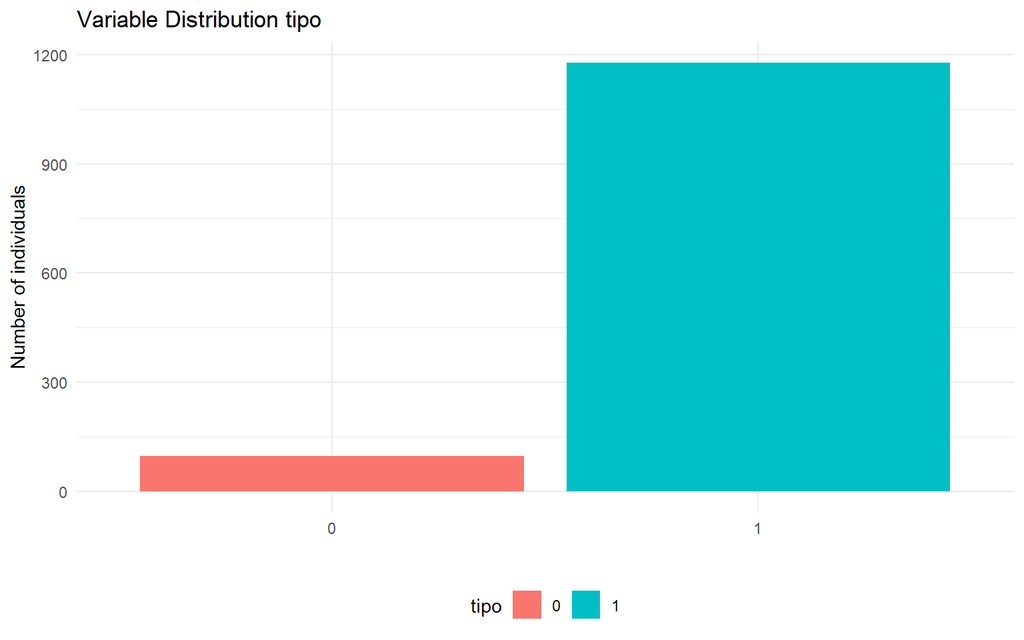

```r
prediction.variable.balance(datos_tumores,"tipo")
```

Es un problema desbalanceado debido a que hay muchas más observaciones que poseen un tumor que las que no poseen un tumor.

```r
muestra <- createDataPartition(y = datos_tumores$tipo, p = 0.75, list = F)
tabla_testing <- datos_tumores[muestra,]
tabla_aprendizaje <- datos_tumores[-muestra,]
tabla_testing <- tabla_testing[,-1]
tabla_aprendizaje <- tabla_aprendizaje[,-1]
```

Se aplica el método de K vecinos más cercanos.

```r
modelo <- train.knn(tipo~., data = tabla_aprendizaje,
                    kmax = floor(sqrt(nrow(tabla_aprendizaje))))
modelo
```

```
##
## Call:
## kknn::train.kknn(formula = tipo ~ ., data = tabla_aprendizaje,     kmax = floor(sqrt(nrow(tabla_aprendizaje))))
##
## Type of response variable: nominal
## Minimal misclassification: 0.06289308
## Best kernel: optimal
## Best k: 9
```

Se realiza la predicción.

```r
prediccion   <- predict(modelo, tabla_testing, type = "class")
head(prediccion$prediction)
```

```
## [1] 1 1 1 1 1 1
## Levels: 0 1
```

Se realiza la matriz de confusión.

```r
matriz_confusion <- confusion.matrix(tabla_testing, prediccion)
```

Se calculan los índices de calidad de la predicción.

```r
general.indexes(mc = matriz_confusion)
```

```
##
## Confusion Matrix:
##     prediction
## real   0   1
##    0  19  54
##    1  13 871
##
## Overall Accuracy: 0.9300
## Overall Error:    0.0700
##
## Category Accuracy:
##
##             0            1
##      0.260274     0.985294
```

## 3. Genere un Modelo Predictivo usando K vecinos más cercanos para cada uno de los siguientes núcleos: rectangular, triangular, epanechnikov, biweight, triweight, cos, inv, gaussian y optimal ¿Cuál produce los mejores resultados en el sentido de que predice mejor los tumores, es decir, Tumor = 1?

### Rectangular

```r
modelo_rectangular <- train.knn(tipo~., data = tabla_aprendizaje,
                    kmax = floor(sqrt(nrow(tabla_aprendizaje))),
                    kernel = "rectangular")
prediccion_rectangular <- predict(modelo_rectangular, tabla_testing,
                                    type = "class")
matriz_confusion_rectangular <- confusion.matrix(tabla_testing,
                                                 prediccion_rectangular)

indices_rectangular <- general.indexes(mc = matriz_confusion_rectangular)

indices_rectangular
```

```
##
## Confusion Matrix:
##     prediction
## real   0   1
##    0  10  63
##    1   5 879
##
## Overall Accuracy: 0.9289
## Overall Error:    0.0711
##
## Category Accuracy:
##
##             0            1
##      0.136986     0.994344
```

### Triangular

```r
modelo_triangular <- train.knn(tipo~., data = tabla_aprendizaje,
                                kmax = floor(sqrt(nrow(tabla_aprendizaje))),
                                kernel = "triangular")
prediccion_triangular <- predict(modelo_triangular, tabla_testing,
                                    type = "class")
matriz_confusion_triangular <- confusion.matrix(tabla_testing,
                                                 prediccion_triangular)

indices_triangular <- general.indexes(mc = matriz_confusion_triangular)

indices_triangular
```

```
##
## Confusion Matrix:
##     prediction
## real   0   1
##    0  18  55
##    1  10 874
##
## Overall Accuracy: 0.9321
## Overall Error:    0.0679
##
## Category Accuracy:
##
##             0            1
##      0.246575     0.988688
```

### Epanechnikov

```r
modelo_epanechnikov <- train.knn(tipo~., data = tabla_aprendizaje,
                               kmax = floor(sqrt(nrow(tabla_aprendizaje))),
                               kernel = "epanechnikov")
prediccion_epanechnikov <- predict(modelo_epanechnikov, tabla_testing,
                                   type = "class")
matriz_confusion_epanechnikov <- confusion.matrix(tabla_testing,
                                                prediccion_epanechnikov)

indices_epanechnikov <- general.indexes(mc = matriz_confusion_epanechnikov)

indices_epanechnikov
```

```
##
## Confusion Matrix:
##     prediction
## real   0   1
##    0  21  52
##    1  15 869
##
## Overall Accuracy: 0.9300
## Overall Error:    0.0700
##
## Category Accuracy:
##
##             0            1
##      0.287671     0.983032
```

### Biweight

```r
modelo_biweight <- train.knn(tipo~., data = tabla_aprendizaje,
                                 kmax = floor(sqrt(nrow(tabla_aprendizaje))),
                                 kernel = "biweight")
prediccion_biweight <- predict(modelo_biweight, tabla_testing,
                                     type = "class")
matriz_confusion_biweight <- confusion.matrix(tabla_testing,
                                                  prediccion_biweight)

indices_biweight <- general.indexes(mc = matriz_confusion_biweight)

indices_biweight
```

```
##
## Confusion Matrix:
##     prediction
## real   0   1
##    0  18  55
##    1  11 873
##
## Overall Accuracy: 0.9310
## Overall Error:    0.0690
##
## Category Accuracy:
##
##             0            1
##      0.246575     0.987557
```

### Triweight

```r
modelo_triweight <- train.knn(tipo~., data = tabla_aprendizaje,
                             kmax = floor(sqrt(nrow(tabla_aprendizaje))),
                             kernel = "triweight")
prediccion_triweight <- predict(modelo_triweight, tabla_testing,
                                 type = "class")
matriz_confusion_triweight <- confusion.matrix(tabla_testing,
                                              prediccion_triweight)

indices_triweight <- general.indexes(mc = matriz_confusion_triweight)

indices_triweight
```

```
##
## Confusion Matrix:
##     prediction
## real   0   1
##    0  20  53
##    1  11 873
##
## Overall Accuracy: 0.9331
## Overall Error:    0.0669
##
## Category Accuracy:
##
##             0            1
##      0.273973     0.987557
```

### Cos

```r
modelo_cos <- train.knn(tipo~., data = tabla_aprendizaje,
                              kmax = floor(sqrt(nrow(tabla_aprendizaje))),
                              kernel = "cos")
prediccion_cos <- predict(modelo_cos, tabla_testing,
                                  type = "class")
matriz_confusion_cos <- confusion.matrix(tabla_testing,
                                               prediccion_cos)

indices_cos <- general.indexes(mc = matriz_confusion_cos)

indices_cos
```

```
##
## Confusion Matrix:
##     prediction
## real   0   1
##    0  16  57
##    1  10 874
##
## Overall Accuracy: 0.9300
## Overall Error:    0.0700
##
## Category Accuracy:
##
##             0            1
##      0.219178     0.988688
```

### Inv

```r
modelo_inv <- train.knn(tipo~., data = tabla_aprendizaje,
                        kmax = floor(sqrt(nrow(tabla_aprendizaje))),
                        kernel = "inv")
prediccion_inv <- predict(modelo_inv, tabla_testing,
                            type = "class")
matriz_confusion_inv <- confusion.matrix(tabla_testing,
                                         prediccion_inv)

indices_inv <- general.indexes(mc = matriz_confusion_inv)

indices_inv
```

```
##
## Confusion Matrix:
##     prediction
## real   0   1
##    0  26  47
##    1  13 871
##
## Overall Accuracy: 0.9373
## Overall Error:    0.0627
##
## Category Accuracy:
##
##             0            1
##      0.356164     0.985294
```

### Gaussian

```r
modelo_gaussian <- train.knn(tipo~., data = tabla_aprendizaje,
                        kmax = floor(sqrt(nrow(tabla_aprendizaje))),
                        kernel = "gaussian")
prediccion_gaussian <- predict(modelo_gaussian, tabla_testing,
                            type = "class")
matriz_confusion_gaussian <- confusion.matrix(tabla_testing,
                                         prediccion_gaussian)

indices_gaussian <- general.indexes(mc = matriz_confusion_gaussian)

indices_gaussian
```

```
##
## Confusion Matrix:
##     prediction
## real   0   1
##    0  17  56
##    1  15 869
##
## Overall Accuracy: 0.9258
## Overall Error:    0.0742
##
## Category Accuracy:
##
##             0            1
##      0.232877     0.983032
```

### Optimal

```r
modelo_optimal <- train.knn(tipo~., data = tabla_aprendizaje,
                             kmax = floor(sqrt(nrow(tabla_aprendizaje))),
                             kernel = "optimal")
prediccion_optimal <- predict(modelo_optimal, tabla_testing,
                                 type = "class")
matriz_confusion_optimal <- confusion.matrix(tabla_testing,
                                              prediccion_optimal)

indices_optimal <- general.indexes(mc = matriz_confusion_optimal)

indices_optimal
```

```
##
## Confusion Matrix:
##     prediction
## real   0   1
##    0  19  54
##    1  13 871
##
## Overall Accuracy: 0.9300
## Overall Error:    0.0700
##
## Category Accuracy:
##
##             0            1
##      0.260274     0.985294
```

Se crea una lista con la exactitud del modelo según el kernel seleccionado para el caso de importancia, el cual es cuando el individuo sí posee un tumor.

```r
indices <- c(rectangular = indices_rectangular$category.accuracy[2],
                triangular = indices_triangular$category.accuracy[2],
                epanechnikov = indices_epanechnikov$category.accuracy[2],
                biweight = indices_biweight$category.accuracy[2],
                triweight = indices_triweight$category.accuracy[2],
                cos = indices_cos$category.accuracy[2],
                inv = indices_inv$category.accuracy[2],
                gaussian = indices_gaussian$category.accuracy[2],
                optimal = indices_optimal$category.accuracy[2])
indices
```

```
##  rectangular.1   triangular.1 epanechnikov.1     biweight.1    triweight.1
##      0.9943439      0.9886878      0.9830317      0.9875566      0.9875566
##          cos.1          inv.1     gaussian.1      optimal.1
##      0.9886878      0.9852941      0.9830317      0.9852941
```

Se obtiene el máximo.

```r
max(indices)
```

```
## [1] 0.9943439
```

El kernel que produce los mejores resultados en el sentido de que predice mejor los tumores es el rectangular con un 99.43% de casos acertados, lo cual es bastante bueno debido a la importancia de la predicción en este tema específico. Note que, el kernel que trae la función por defecto es el optimal que tiene un poder predictivo de casos positivos menor.

# Ejercicio 4

**1. Cargue la tabla de datos titanicV2024.csv, asegúrese de re-codificar las variables cualitativas y de ignorar variables que no se deben usar**

Se carga la base de datos.

```r
titanic_datos <- read.csv("titanicV2024.csv", header = TRUE, sep = ",", dec = ".")
head(titanic_datos)
```

```
##   PassengerId Survived Pclass
## 1           1        0      3
## 2           2        1      1
## 3           3        1      3
## 4           4        1      1
## 5           5        0      3
## 6           6        0      3
##                                                  Name    Sex Age SibSp Parch
## 1                             Braund, Mr. Owen Harris   male  22     1     0
## 2 Cumings, Mrs. John Bradley (Florence Briggs Thayer) female  38     1     0
## 3                              Heikkinen, Miss. Laina female  26     0     0
## 4        Futrelle, Mrs. Jacques Heath (Lily May Peel) female  35     1     0
## 5                            Allen, Mr. William Henry   male  35     0     0
## 6                                    Moran, Mr. James   male  NA     0     0
##             Ticket    Fare Cabin Embarked
## 1        A/5 21171  7.2500  <NA>        S
## 2         PC 17599 71.2833   C85        C
## 3 STON/O2. 3101282  7.9250  <NA>        S
## 4           113803 53.1000  C123        S
## 5           373450  8.0500  <NA>        S
## 6           330877  8.4583  <NA>        Q
```

Se eliminan las variables Passengerid, Name, Ticket y Cabin, pues, son valores únicos implicando que la cantidad de categorías por variables sean demasiadas, lo cual, resta precisión.

```r
titanic_datos <- titanic_datos[, -c(1,4,9,11)]
```

Se re-codifican las variables cualitativas para que sean de tipo factor.

```r
titanic_datos <- titanic_datos %>%
   mutate(Survived =  as.factor(Survived),
          Pclass =  as.factor(Pclass),
          Sex =  as.factor(Sex),
          Embarked =  as.factor(Embarked))
str(titanic_datos)
```

```
## 'data.frame':    1309 obs. of  8 variables:
##  $ Survived: Factor w/ 2 levels "0","1": 1 2 2 2 1 1 1 1 2 2 ...
##  $ Pclass  : Factor w/ 3 levels "1","2","3": 3 1 3 1 3 3 1 3 3 2 ...
##  $ Sex     : Factor w/ 2 levels "female","male": 2 1 1 1 2 2 2 2 1 1 ...
##  $ Age     : num  22 38 26 35 35 NA 54 2 27 14 ...
##  $ SibSp   : int  1 1 0 1 0 0 0 3 0 1 ...
##  $ Parch   : int  0 0 0 0 0 0 0 1 2 0 ...
##  $ Fare    : num  7.25 71.28 7.92 53.1 8.05 ...
##  $ Embarked: Factor w/ 3 levels "C","Q","S": 3 1 3 3 3 2 3 3 3 1 ...
```

Se identican la cantidad de NA’s presentes en cada variable.

```r
na_variables <- colSums(is.na(titanic_datos))
print(na_variables)
```

```
## Survived   Pclass      Sex      Age    SibSp    Parch     Fare Embarked
##        0        0        0      263        0        0        1        2
```

De acuerdo con los mostrado, la variable Age cuenta con datos faltantes. Por tal motivo, se procede a rellenarlos con el promedio de las edades según el sexo.

```r
# Se filtran las edades
mujeres_edades <- na.omit(titanic_datos$Age[titanic_datos$Sex == "female"])
hombres_edades <- na.omit(titanic_datos$Age[titanic_datos$Sex == "male"])

# Se calculan los promedios de las edades
edad_promedio_mujeres <- round(mean(mujeres_edades))
edad_promedio_hombres <- round(mean(hombres_edades))

# Se rellenan los datos faltantes
titanic_datos$Age[titanic_datos$Sex == "female" & is.na(titanic_datos$Age)] <- edad_promedio_mujeres
titanic_datos$Age[titanic_datos$Sex == "male" & is.na(titanic_datos$Age)] <- edad_promedio_hombres
```

También, la variable Embarked presenta dos variables faltantes. Se rellenan con la moda de las cateogrías.

```r
# Se obtiene la moda para la variable Embarked
tabla_frec <- table(titanic_datos$Embarked)  # Se calcula la tabla de frecuencias
moda  <- names(tabla_frec)[which.max(tabla_frec)]  # Encontrar el valor con la frecuencia más alta

# Se rellena el dato faltante
titanic_datos$Embarked[is.na(titanic_datos$Embarked)] <- moda
```

Finalmente, el dato faltante en Fare se rellena con el promedio de las tarifas según el tipo de clase en que viajaba.

```r
# Se identifica la clase en que viajaba
clase <- titanic_datos$Pclass[is.na(titanic_datos$Fare)]

# Se filtran las tarifas según el tipo de clase de viaje
tarifas <- na.omit(titanic_datos$Fare[titanic_datos$Pclass == clase])

# Se obtiene el promedio de las tarifas
tarifa_promedio <- mean(tarifas)

# Se rellena el dato faltante
titanic_datos$Fare[is.na(titanic_datos$Fare)] <- tarifa_promedio
```

**2. Realice un análisis exploratorio (estadísticas básicas) que incluya: el resumen numérico (media, desviación estándar, etc.), los valores atípicos, la correlación entre las variables, el poder predictivo de las variables predictoras. Interprete los resultados**

Seguidamente, se realiza un análisis exploratorio de los datos para conocer ciertas características y comportamientos de la información con la que contamos.

Primeramente, se presenta un resumen númerico de las variables de la base de datos que brinda información como la media, máximo, mínimo entre otros.

```r
summary(titanic_datos)
```

```
##  Survived Pclass      Sex           Age            SibSp            Parch
##  0:815    1:323   female:466   Min.   : 0.17   Min.   :0.0000   Min.   :0.000
##  1:494    2:277   male  :843   1st Qu.:22.00   1st Qu.:0.0000   1st Qu.:0.000
##           3:709                Median :30.00   Median :0.0000   Median :0.000
##                                Mean   :29.99   Mean   :0.4989   Mean   :0.385
##                                3rd Qu.:35.00   3rd Qu.:1.0000   3rd Qu.:0.000
##                                Max.   :80.00   Max.   :8.0000   Max.   :9.000
##       Fare         Embarked
##  Min.   :  0.000   C:270
##  1st Qu.:  7.896   Q:123
##  Median : 14.454   S:916
##  Mean   : 33.280
##  3rd Qu.: 31.275
##  Max.   :512.329
```

Segundo, se verifica si existen outliers entre las variables. Es decir, si se presentan valores atípicos que se alejan del resto de los datos. Para esto, es útil construir la caja de bigotes correspondiente a cada variable númerica ya que, nos permiten visualizar de manera sencilla si existen estos tipos de datos.

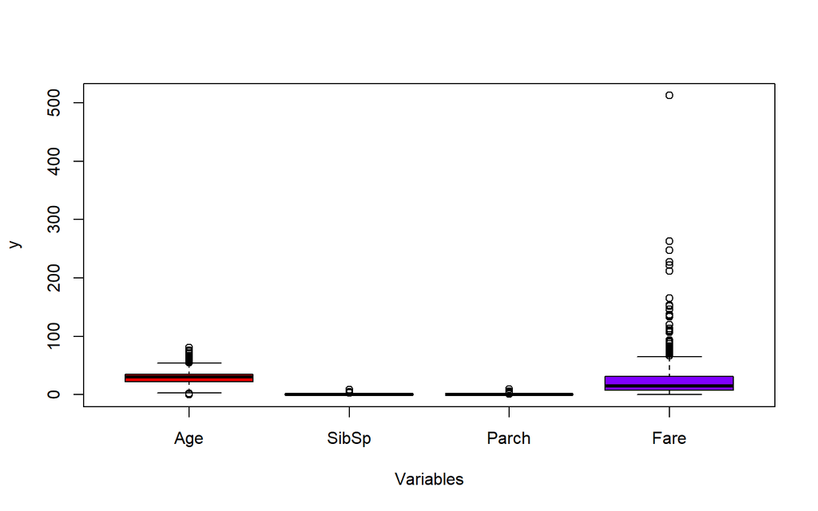

```r
titanic_datos_num <- titanic_datos[, c(4,5,6,7)]
stacked_titanic <- stack(titanic_datos_num)
boxplot(stacked_titanic$values ~ stacked_titanic$ind,
        col = rainbow(ncol(titanic_datos_num)), xlab = "Variables", ylab ="y")
```

Se puede observar que para la edad hay varios valores atípicos por encima del límite superior(aprox 55) y unos pocos por debajo del límite inferior (aprox 1). Sin embargo, no se eliminan de la base de datos, pues, es sabido que las personas que viajaron en el Titanic eran de diversas edades, no solo rondaban entre los 1 y 55 años.

Para el caso de la cantidad de hermanos o cónyugues a bordo, la media es de 0 aproximadamente y lo máximo de 8 que se aleja mucho de la media, por ese motivo se identifican dos valores atípicos. No obstante, no se eliminan, pues, no se encuentran muy alejados del límite superior y algunas familias solían ser numerosas. Similarmente pasa con la cantidad de padres o hijos a bordo del Titanic. Por tanto, tampoco se eliminan los outliers de esta variable.

```r
titanic_datos <- titanic_datos[-(titanic_datos$Fare == max(titanic_datos$Fare)),]
```

Tercero, se realiza un gráfico de correlaciones para identificar si hay o no correlaciones entre las variables númericas.

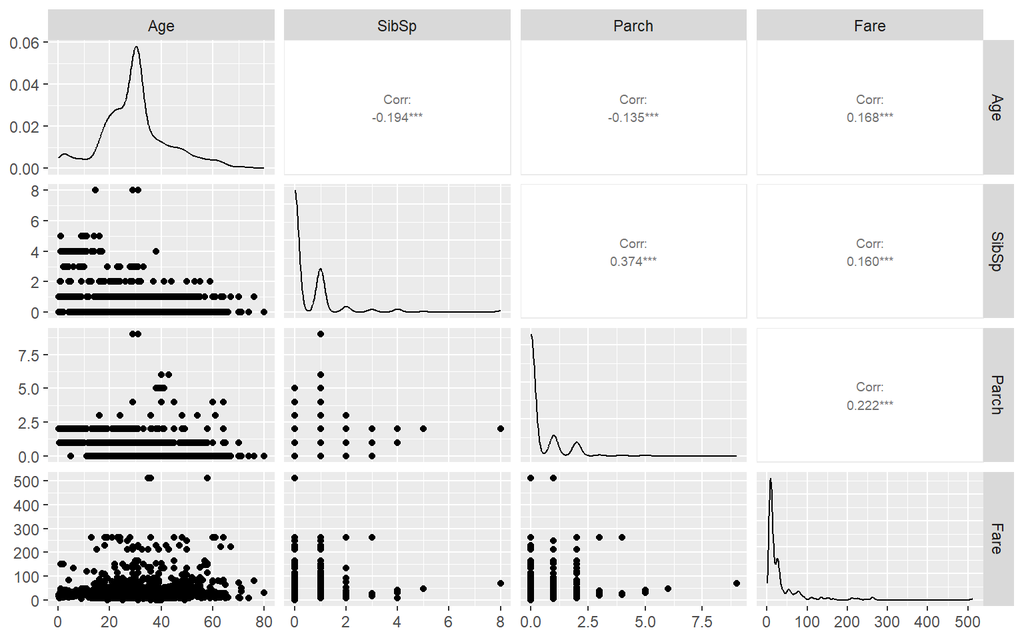

```r
ggpairs(titanic_datos_num,  upper = list(continuous = wrap("cor", size = 2.5)))
```

Del gráfico anterior se puede identificar que Age tiene una correlación negativa con SibSp y Parch, es decir, que conforme una variable aumenta la otra disminuye. Y tiene una relación positiva con Fare, lo que significa que ambas se comportan de manera proporcional.

Además, SibSp tiene una relación positiva con Parch y Fare. Entonces, si incrementa la cantidad de hermanos o cónyuges también aumenta la cantidad de hijos o padres y la tarifa.

Por último, Parch tiene una correlación positiva con Fare, por ende, si aumenta la cantidad de hijos o padres también sube la tarifa.

Finalmente, se analiza el poder predictor de las variables. Es decir, la capacidad de las variables para predecir si el pasajero del Titanic sobrevivió o no.

Para ese objetivo, se presentan los siguientes gráficos:

```r
titanic_datos_num_pred <- titanic_datos[, c(1,4,5,6,7)]
titanic_datos_cat_pred <- titanic_datos[, c(1,2,3,8)]

colnames(titanic_datos_num_pred)[1] <- "Survived"
colnames(titanic_datos_cat_pred)[1] <- "Survived"

lista_num_poder_pred <- list()
for (i in 2:ncol(titanic_datos_num_pred)) {
  variable  <- names(titanic_datos_num_pred)[i]
  lista_num_poder_pred[[i-1]] <- numerical.predictive.power(titanic_datos_num_pred, "Survived", variable)
}

lista_cat_poder_pred <- list()
for (i in 2:ncol(titanic_datos_cat_pred)) {
  variable  <- names(titanic_datos_cat_pred)[i]
  lista_cat_poder_pred[[i-1]] <- categorical.predictive.power(titanic_datos_cat_pred, "Survived", variable)
}
```

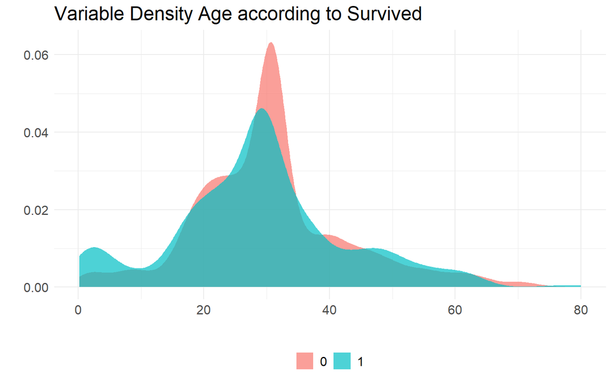

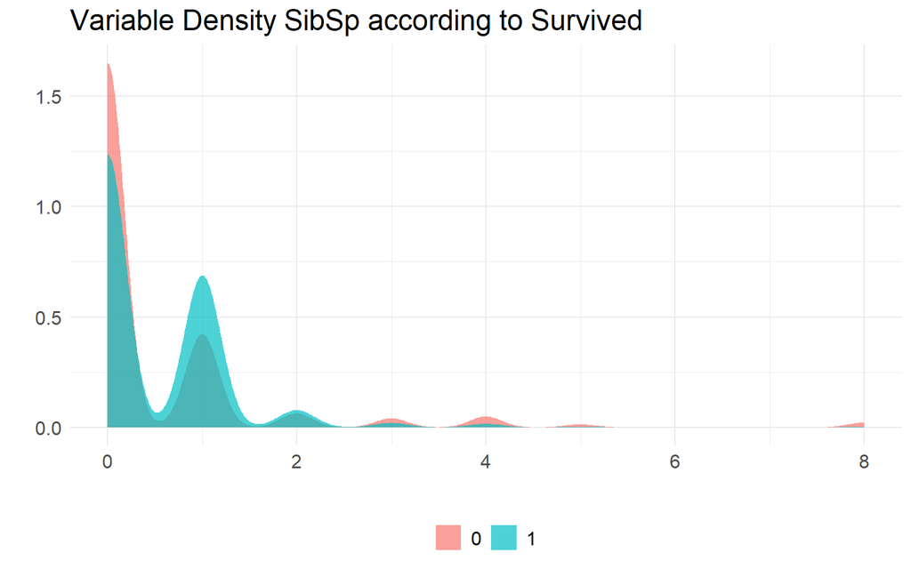

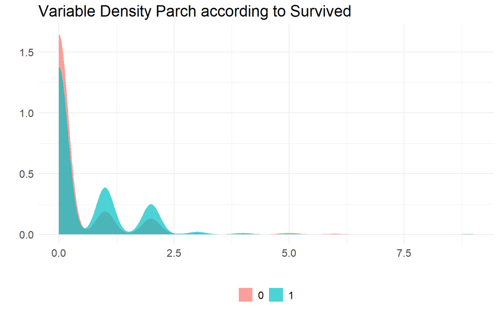

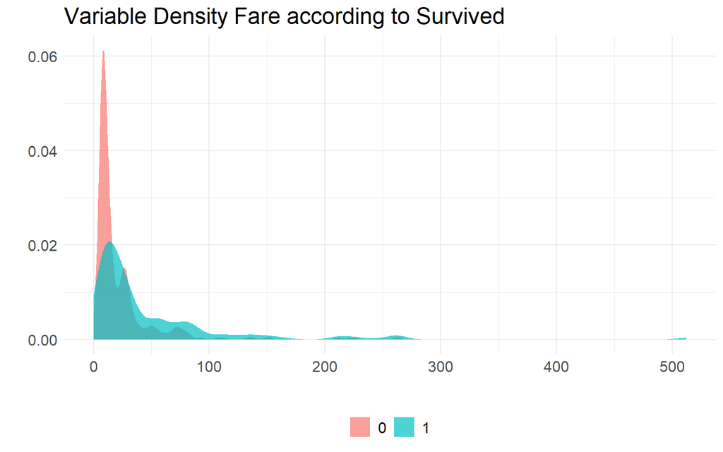

```r
lista_num_poder_pred
```

En todos los gráficos se tiene una grande sobreposición de las densidades. Lo cual, significa que el poder predictivo de las variables númericas es poco.Por esa razón, no se considerarán esas variables en la predicción.

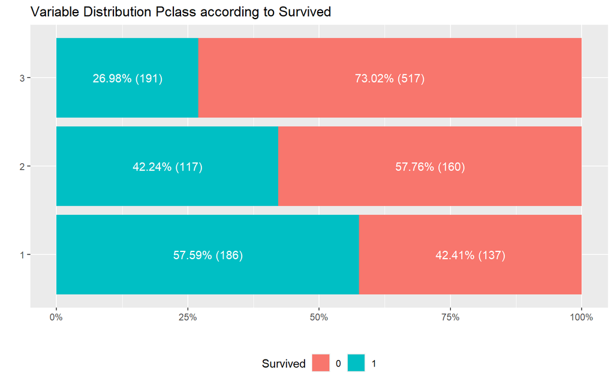

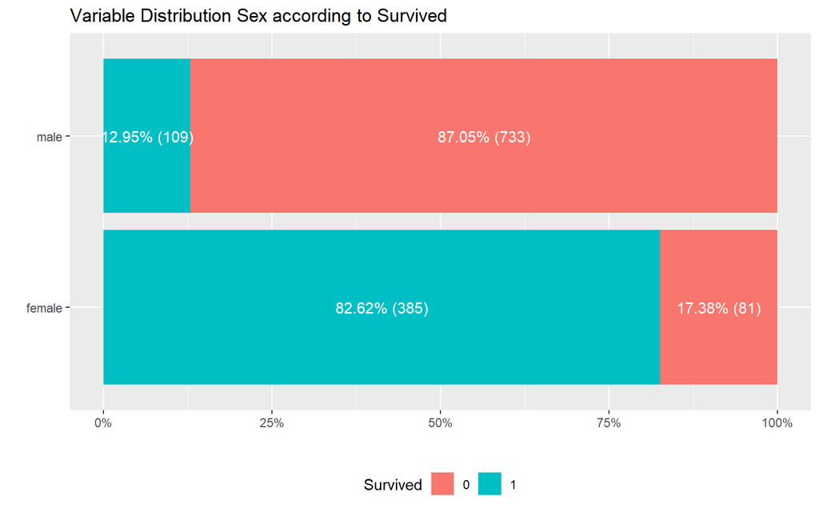

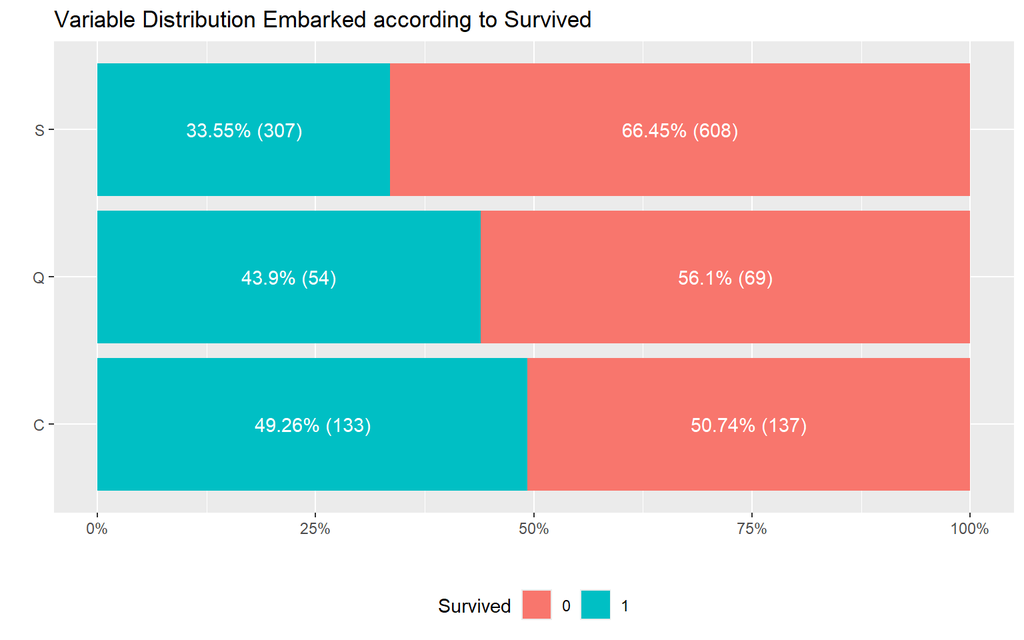

```r
lista_cat_poder_pred
```

En cuanto a las variables categóricas, se puede determinar que todas tienen poder de predicción, pues, la proporción de las barras son distintas en cada categoría. Entonces, todas esas variables se tomarán en cuenta para la predicción.

**3.¿Es este problema equilibrado o desequilibrado? Justifique su respuesta**

El siguiente gráfico permite identificar si el problema está o no equilibrado.

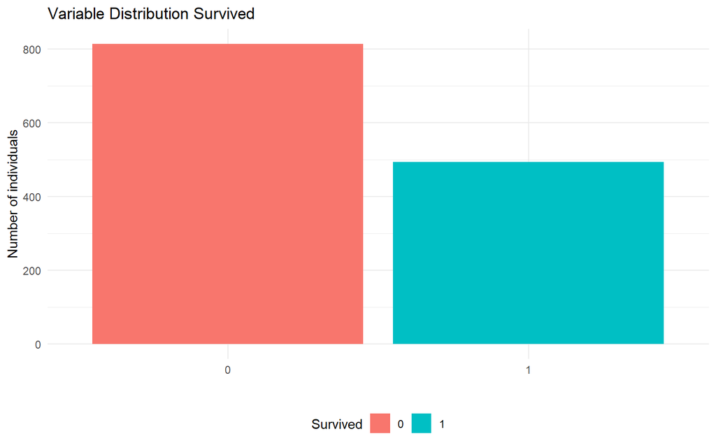

```r
prediction.variable.balance(titanic_datos, "Survived")
```

Es evidente que las barras son de distintos tamaños, la cantidad de sobrevivientes es menor a la de no sobrevivientes. Entonces, se está ante un problema desequilibrado.

**4. Use el método de K vecinos más cercanos en el paquete traineR, con los parámetros que logren el mejor resultado, para generar un modelo predictivo con la tabla titanicV2024.csv usando el 80% de los datos para la tabla aprendizaje y un 20% para la tabla testing, luego calcule para los datos de testing la matriz de confusión, la precisión global y la precisión para cada una de las dos categorías. ¿Son buenos los resultados? Explique.**

Primeramente, se crea una muestra para generar las particiones tabla aprendizaje-testing. Dado que el problema es desequilibrado, se genera la muestra de la siguiente manera:

```r
set.seed(2529) # se siembra una semilla para la reproducibilidad
muestra_titanic <- createDataPartition(y = titanic_datos$Survived, p = 0.80, list = F)
```

Con esa muestra se obtienen las particiones en tabla de aprendizaje y testing.

```r
taprendizaje_titanic <- titanic_datos[muestra_titanic, ]
ttesting_titanic     <- titanic_datos[-muestra_titanic, ]
```

Seguido, se realiza el modelo predictivo mediante el método de k vecinos más cercanos con las variables predictoras que tuvieron mejor poder de predicción indicadas en la parte 2.

```r
modelo_titanic <- train.knn(Survived ~ Pclass + Sex + Embarked, data = taprendizaje_titanic, kmax = floor(sqrt(nrow(taprendizaje_titanic))))
modelo_titanic
```

```
##
## Call:
## kknn::train.kknn(formula = Survived ~ Pclass + Sex + Embarked,     data = taprendizaje_titanic, kmax = floor(sqrt(nrow(taprendizaje_titanic))))
##
## Type of response variable: nominal
## Minimal misclassification: 0.1698473
## Best kernel: optimal
## Best k: 16
```

Luego, se obtienen las predicciones del modelo:

```r
prediccion_titanic <- predict(modelo_titanic, ttesting_titanic, type = "class")
prediccion_titanic$prediction
```

```
##   [1] 0 1 0 0 1 0 0 1 1 0 1 0 0 1 1 0 0 1 0 0 0 0 0 0 0 1 0 1 0 0 0 0 0 0 0 0 1
##  [38] 0 0 0 0 0 0 0 1 1 0 0 0 1 0 0 0 0 1 0 0 1 0 1 1 1 0 1 0 1 0 0 0 1 0 1 0 0
##  [75] 0 0 0 0 0 0 1 0 0 0 0 1 0 0 0 0 0 0 0 0 0 0 0 0 0 1 0 1 0 0 0 1 0 0 0 0 0
## [112] 0 1 1 0 1 0 0 0 0 1 0 0 0 0 0 0 0 0 0 0 1 0 0 1 0 1 0 0 0 0 0 1 0 0 1 0 0
## [149] 0 1 1 0 0 0 0 0 0 1 1 0 0 1 0 1 1 0 0 1 0 0 0 0 0 0 1 0 0 0 0 0 1 0 0 1 1
## [186] 1 0 0 0 0 1 0 1 1 1 1 0 0 0 0 0 0 0 0 0 1 0 1 0 1 1 0 0 0 0 1 0 0 0 0 0 1
## [223] 1 0 1 0 0 0 1 0 0 0 0 0 0 0 0 0 0 0 0 0 0 0 1 0 1 0 0 0 1 0 0 1 0 1 0 1 0
## [260] 1
## Levels: 0 1
```

Se calcula la matriz de confusión que permite identificar la información de las predicciones dada por el modelo y comparar con los datos reales.

```r
matriz_confusion_titanic <- confusion.matrix(ttesting_titanic, prediccion_titanic)
general.indexes(mc = matriz_confusion_titanic)
```

```
##
## Confusion Matrix:
##     prediction
## real   0   1
##    0 160   2
##    1  29  69
##
## Overall Accuracy: 0.8808
## Overall Error:    0.1192
##
## Category Accuracy:
##
##             0            1
##      0.987654     0.704082
```

Se puede observar que el modelo predice bien que 160 pasajeros del Titanic no sobrevivieron pero falla en la predicción de 29 casos. Además, predice correctamente que 69 pasajeros sobrevivieron al incidente pero falló en la predicción de 2. En general, el número de aciertos del modelo para ambas categorías es mayor que la cantidad de fallos, lo cual, parece indicar que el modelo es bueno.

Sin embargo, se deben analizar otras medidas más precisas para determinar qué tan buenos son los resultados del modelo. La función muestra algunos índices de calidad,interpretando se tiene que la Precisión Global (Overaal Accuracy), es decir, el porcentaje de predicciones correctas con respecto al total de predicciones, es de 0.8808 lo que es bastante bueno.

Además, la Precisión Positiva, que corresponde al porcentaje de sobrevivientes predichos correctamente, es de 0.704082 lo cual, también es bueno.

Finalmente, se tiene que la Precisión Negativa, que corresponde al porcentaje de no sobrevivientes predichos correctamente, es de 0.987654 siendo bastante alto y mejor que la predicción de sobrevivientes.

En general, los tres índices de calidad analizados indicaron una buena calidad del modelo para predecir a los pasajeros que sobrevivieron o no.

**5. Repita el item 4), pero esta vez, seleccione las 5 variables que, según su criterio, tienen mejor poder predictivo. ¿Mejoran los resultados?**

En el inciso anterior no se emplearon las variables númericas como predictoras por su poco poder predictivo según lo descrito en la parte 2. De tal manera, se analizarán qué resultados se obtienen si junto con las variables categóricas, que indicaron tener poder predictivo, se añaden dos de esas variables númericas al modelo. Según los gráficos de la parte 2, las variables Age y Fare presentan menos sobreposición de las densidades en comparación con SibSp y Parch, entonces tienen mejor poder predicitivo que esas últimas dos. Por ese motivo, se efectuará de nuevo el modelo ahora con las siguientes 5 variables: Age, Fare, Pclass, Sex y Embarked.

Para esto, se emplea la misma muestra, tabla de aprendizaje y testing de la parte 4. Después, se realiza el modelo predictivo mediante el método de k vecinos más cercanos con las 5 variables predictoras mencionados anteriormente.

```r
modelo_titanic_2 <- train.knn(Survived ~ Age+ Fare + Pclass + Sex + Embarked, data = taprendizaje_titanic, kmax = floor(sqrt(nrow(taprendizaje_titanic))))
modelo_titanic_2
```

```
##
## Call:
## kknn::train.kknn(formula = Survived ~ Age + Fare + Pclass + Sex +     Embarked, data = taprendizaje_titanic, kmax = floor(sqrt(nrow(taprendizaje_titanic))))
##
## Type of response variable: nominal
## Minimal misclassification: 0.1364504
## Best kernel: optimal
## Best k: 11
```

Seguido, se obtienen las predicciones del modelo:

```r
prediccion_titanic_2 <- predict(modelo_titanic_2, ttesting_titanic, type = "class")
prediccion_titanic_2$prediction
```

```
##   [1] 0 1 1 0 1 0 0 1 1 0 1 0 0 1 1 0 0 1 1 0 0 0 0 1 0 1 0 1 0 0 0 0 1 0 0 0 1
##  [38] 1 0 0 0 0 0 0 1 1 0 0 0 1 0 1 0 0 1 0 0 1 0 1 1 1 1 1 0 1 0 1 0 1 0 1 0 0
##  [75] 1 0 1 0 1 0 1 0 0 0 0 1 0 0 0 0 0 0 0 0 0 0 0 1 0 1 0 1 0 0 0 1 0 0 0 0 0
## [112] 1 1 1 0 1 0 0 0 1 1 0 0 0 1 0 0 0 0 0 0 1 0 0 1 0 1 0 0 0 0 0 1 0 1 1 0 0
## [149] 0 1 1 1 0 0 1 0 0 1 1 0 0 1 0 1 1 0 0 1 0 0 0 0 0 0 1 1 0 1 0 1 1 0 0 1 1
## [186] 1 0 0 0 0 1 0 1 1 1 1 0 0 0 0 0 0 0 1 0 1 0 1 0 1 1 0 0 1 0 1 0 0 0 0 0 1
## [223] 1 0 1 0 1 0 1 1 0 0 0 0 0 0 0 0 0 0 0 0 0 1 1 0 1 0 0 0 1 0 0 1 0 1 0 1 1
## [260] 1
## Levels: 0 1
```

Se calcula la matriz de confusión que permite identificar la información de las predicciones dada por el modelo y comparar con los datos reales.

```r
matriz_confusion_titanic_2 <- confusion.matrix(ttesting_titanic, prediccion_titanic_2)
general.indexes(mc = matriz_confusion_titanic_2)
```

```
##
## Confusion Matrix:
##     prediction
## real   0   1
##    0 146  16
##    1  16  82
##
## Overall Accuracy: 0.8769
## Overall Error:    0.1231
##
## Category Accuracy:
##
##             0            1
##      0.901235     0.836735
```

Se puede observar que el modelo predice bien que 146 pasajeros del Titanic no sobrevivieron pero falla en la predicción de 16 casos. Además, predice correctamente que 82 pasajeros sobrevivieron al incidente pero falló en la predicción de 16. En general, el número de aciertos del modelo para ambas categorías es mayor que la cantidad de fallos, lo cual, parece indicar que el modelo es bueno.

Sin embargo, se deben analizar otras medidas más precisas para determinar qué tan buenos son los resultados del modelo. La función muestra algunos índices de calidad, interpretando se tiene que la Precisión Global (Overaal Accuracy) es de 0.8769 lo que es bastante bueno pero es menor que la dada en el modelo anterior.

Además, la Precisión Positiva es de 0.836735 lo cual, también es bueno y es mejor que la obtenida con el modelo anterior.

Finalmente, se tiene que la Precisión Negativa es de 0.901235 lo que sigue siendo alto pero es más pequeña que la indicada en el otro modelo.

En general, los tres índices de calidad analizados indicaron una buena calidad del modelo para predecir a los pasajeros que sobrevivieron o no.

Comparando el primer modelo con este, el modelo 1 es mejor si se quiere predecir si no sobrevivieron y el modelo 2 es mejor prediciendo a los sobrevivientes. Si se basa en la cantidad de índices que presentan mejor resultado, en ese caso el modelo 1 es mejor.

**6.Usando la función programada en el ejercicio 2, los datos titanicV2024.csv y los modelos generados arriba construya un DataFrame de manera que en cada una de las filas aparezca un modelo predictivo y en las columnas aparezcan los índices Precisión Global, Error Global Precisión Positiva (PP), Precisión Negativa (PN), Falsos Positivos (FP), los Falsos Negativos (FN), la Asertividad Positiva (AP) y la Asertividad Negativa (AN). ¿Cuál de los modelos es mejor para estos datos?**

El dataframe con la información de los índices de calidad de cada modelo es el siguiente:

```r
# Se obtienen los índices de calidad de cada modeo
ind_modelo1 <- indices_matriz(matriz_confusion_titanic)
ind_modelo2 <- indices_matriz(matriz_confusion_titanic_2)

# Se convierte en dataframes
ind_modelo1 <- as.data.frame(ind_modelo1)
ind_modelo2 <- as.data.frame(ind_modelo2)

# Se unen los dos dataframes
indices_modelos <- rbind(ind_modelo1, ind_modelo2)

# Se crea un vector con el nombre de los modelos
nombre_modelo <- c("Modelo 1", "Modelo 2")

# Se une con los dataframes para crear un solo dataframe
indices_modelos <- cbind(nombre_modelo, indices_modelos)
names(indices_modelos) <- c("Modelo", "Precisión Global", "Erro Global",
                            "Precisión Positiva", "Precisión Negativa",
                            "Proporción de Falsos Positivos",
                            "Proporción de Falsos Negativos",
                             "Asertividad Positiva","Asertividad Negativa")
indices_modelos
```

```
##     Modelo Precisión Global Erro Global Precisión Positiva Precisión Negativa
## 1 Modelo 1        0.8807692   0.1192308          0.7040816          0.9876543
## 2 Modelo 2        0.8769231   0.1230769          0.8367347          0.9012346
##   Proporción de Falsos Positivos Proporción de Falsos Negativos
## 1                     0.01234568                      0.2959184
## 2                     0.09876543                      0.1632653
##   Asertividad Positiva Asertividad Negativa
## 1            0.9718310            0.8465608
## 2            0.8367347            0.9012346
```

A partir del dataframe se puede observar que el Modelo 1 da mejores resultados para la Precisión Global y Error Global, pues, el índice de este es más pequeño. También, da mejor Precisión Negativa y Asertividad Positiva. El índice de Falsos Positivos es mejor, ya que, presenta un valor menor.

En cambio, el Modelo 2 es mejor con el índice de Precisión Positiva y Proporción de Falsos negativos porque el valor de este es menor que la del Modelo 1. Además, brinda mejor resultado para la Asertividad Negativa.

Si se considera la cantidad de mejores índices obtenidos de la comparación de los modelos, el Modelo 1 es el que brinda mejores resultados. No obstante, depende del tipo de análisis que se pretenda realiza para determinar cuál modelo es más apto.

# Ejercicio 5

**En este ejercicio vamos a predecir números escritos a mano (Hand Written Digit Recognition), la tabla de aprendizaje está en el archivo ZipDataTrainCod.csv y la tabla de testing está en el archivo ZipDataTestCod.csv.**

## Carga de datos

Primeramente se procede a cargar tanto los datos de entrenamiento como los de prueba.

```r
train_data <- read.csv("ZipDataTrainCod.csv", sep = ";", dec='.', header = T, stringsAsFactors = TRUE)

test_data <- read.csv("ZipDataTestCod.csv", sep = ";", dec='.', header = T, stringsAsFactors = TRUE)
```

## Inciso 1

**Usando K vecinos más cercanos genere un modelo predictivo para la tabla de aprendizaje, con los parámetros que usted estime más convenientes.**

Se procede a generar el modelo con los datos de entrenamiento. Para este modelo se utilizarán los 21 vecinos más cercanos. El número de *k* es de preferencia impar según lo visto en clase. Se utilizarán todas las variables, es decir los 256 píxeles y todas las observaciones que constituyen un total de 7291.

```r
model <- train.knn(Numero~., data = train_data, kmax = 21)
```

## Inciso 2

**Con la tabla de testing calcule la matriz de confusión, la precisión global, el error global y la precisión en cada unos de los dígitos. ¿Son buenos los resultados?**

Ahora se procede a generar las predicciones con base en el modelo creado. Esto para lograr generar la matriz de confusión y medir los resultados obtenidos.

```r
prediction   <- predict(model, test_data, type = "class")
```

Finalmente se procede a generar la matriz de confusión y con ella los niveles de precisión del modelo.

```r
# Se obtiene la matriz de confusión.
CM <- confusion.matrix(test_data, prediction)

# Se calculan los resultados de la precisión.
results <- general.indexes(mc = CM)[c(2,3)]

# Se generan df para mostrar los resultados.
df_CM <- as.data.frame.matrix(CM)
df_results <- data.frame(results[1], results[2])

knitr::kable(df_CM)
```

|  | cero | cinco | cuatro | dos | nueve | ocho | seis | siete | tres | uno |
| --- | --- | --- | --- | --- | --- | --- | --- | --- | --- | --- |
| cero | 353 | 1 | 0 | 3 | 1 | 0 | 0 | 1 | 0 | 0 |
| cinco | 4 | 139 | 0 | 1 | 1 | 6 | 1 | 3 | 4 | 1 |
| cuatro | 1 | 1 | 177 | 4 | 10 | 0 | 1 | 3 | 0 | 3 |
| dos | 6 | 2 | 0 | 176 | 0 | 6 | 2 | 5 | 1 | 0 |
| nueve | 1 | 0 | 2 | 0 | 168 | 1 | 0 | 5 | 0 | 0 |
| ocho | 5 | 2 | 0 | 3 | 2 | 147 | 0 | 3 | 4 | 0 |
| seis | 5 | 2 | 1 | 3 | 0 | 0 | 159 | 0 | 0 | 0 |
| siete | 0 | 0 | 4 | 1 | 1 | 1 | 0 | 139 | 1 | 0 |
| tres | 2 | 7 | 0 | 4 | 2 | 0 | 0 | 1 | 150 | 0 |
| uno | 0 | 0 | 6 | 0 | 0 | 0 | 2 | 1 | 0 | 255 |

```r
knitr::kable(df_results)
```

| overall.accuracy | overall.error |
| --- | --- |
| 0.9282511 | 0.0717489 |

Como se puede observar, el nivel de error es relativamente bajo y la precisión es bastante acertada. Según se indicó en el inciso, el error debe ser sumamente bajo para evitar errores en el envío de los paquetes. Asumiendo que se contaba con este modelo desde el principio, contemplando que existe un total de 9298 observaciones y teniendo en cuenta el error aproximado de 0.072, entonces se tiene que al rededor de 665 números serías clasificados de manera errónea lo que implicaría que, como máximo, cerca 665 paquetes paquetes serían enviados a la dirección incorrecta, lo que para una empresa postal sería fatal pues representa un número alto de clientes insatisfechos. Por lo tanto, dados los resultados de este modelo, se preferiría la observación humana sobre el algoritmo.

Ahora probemos utilizando la raíz cuadrada de la cantidad de observaciones.

```r
# Se genera el modelo.
model_2 <- train.knn(Numero~., data = train_data,
                     kmax = floor(sqrt(nrow(train_data))),
                     kernel = "optimal")

# Se obtienen las predicciones.
prediction_2   <- predict(model_2, test_data, type = "class")

# Se obtiene la matriz de confusión.
CM_2 <- confusion.matrix(test_data, prediction_2)

# Se calculan los resultados de la precisión.
results_2 <- general.indexes(mc = CM_2)[c(2,3)]

# Se generan df para mostrar los resultados.
df_CM_2 <- as.data.frame.matrix(CM_2)
df_results_2 <- data.frame(results_2[1], results_2[2])

knitr::kable(df_CM_2)
```

|  | cero | cinco | cuatro | dos | nueve | ocho | seis | siete | tres | uno |
| --- | --- | --- | --- | --- | --- | --- | --- | --- | --- | --- |
| cero | 353 | 1 | 0 | 3 | 1 | 0 | 0 | 1 | 0 | 0 |
| cinco | 4 | 139 | 0 | 1 | 1 | 6 | 1 | 3 | 4 | 1 |
| cuatro | 1 | 1 | 177 | 4 | 10 | 0 | 1 | 3 | 0 | 3 |
| dos | 6 | 2 | 0 | 176 | 0 | 6 | 2 | 5 | 1 | 0 |
| nueve | 1 | 0 | 2 | 0 | 168 | 1 | 0 | 5 | 0 | 0 |
| ocho | 5 | 2 | 0 | 3 | 2 | 147 | 0 | 3 | 4 | 0 |
| seis | 5 | 2 | 1 | 3 | 0 | 0 | 159 | 0 | 0 | 0 |
| siete | 0 | 0 | 4 | 1 | 1 | 1 | 0 | 139 | 1 | 0 |
| tres | 2 | 7 | 0 | 4 | 2 | 0 | 0 | 1 | 150 | 0 |
| uno | 0 | 0 | 6 | 0 | 0 | 0 | 2 | 1 | 0 | 255 |

```r
knitr::kable(df_results_2)
```

| overall.accuracy | overall.error |
| --- | --- |
| 0.9282511 | 0.0717489 |

Como se evidencia, los resultados son los mismos, por lo tanto, no es necesario el uso de un número mayor $k$ para los cálculos. En este caso, la conclusión en la misma que la anterior.

## Inciso 3

**Repita los items 1) y 2) pero usando solamente los 3s, 5s y los 8s. ¿Mejora la predicción?**

Se procede a extraer 2 *sub-sets* de datos en los que solo se encuentra infromación respecto a los 3s, 5s y 8s.

```r
# Vector con los números a utilizar.
nums <- c("tres", "cinco", "ocho")

# Se filtra el set de datos para entrenamiento.
train_data_nums <- train_data %>% filter(Numero %in% nums) %>% droplevels()

# Se filtra el set de datos para pruebas.
test_data_nums <- test_data %>% filter(Numero %in% nums) %>% droplevels()
```

Finalmente se procede a repetir lo realizado en los incisos anteriores.

```r
# Se genera el modelo.
model_nums <- train.knn(Numero~., data = train_data_nums, kmax = 21)

# Se obtienen las predicciones.
prediction_nums   <- predict(model_nums, test_data_nums, type = "class")

# Se obtiene la matriz de confusión.
CM_nums <- confusion.matrix(test_data_nums, prediction_nums)

# Se calculan los resultados de la precisión.
results_nums <- general.indexes(mc = CM_nums)[c(2,3)]

# Se generan df para mostrar los resultados.
df_CM_nums <- as.data.frame.matrix(CM_nums)
df_results_nums <- data.frame(results_nums[1], results_nums[2])

knitr::kable(df_CM_nums)
```

|  | cinco | ocho | tres |
| --- | --- | --- | --- |
| cinco | 149 | 4 | 7 |
| ocho | 2 | 160 | 4 |
| tres | 10 | 0 | 156 |

```r
knitr::kable(df_results_nums)
```

| overall.accuracy | overall.error |
| --- | --- |
| 0.945122 | 0.054878 |

Tal y como se muestra, para los números 3, 5 y 8, el nivel de precisión aumenta. Nuevamente bajo la misma lógica del inciso anterior, si se contara con este modelo desde el inicio y contemplando la tasa de error de aproximadamente 0.055, de los números predichos, cerca de 123 serían erróneos, lo cual representa, como máximo, 123 paquetes enviados incorrectamente, que aunque es un máximo, resulta inaceptable para una compañía postal.

## Inciso 4

**Repita los items 1) y 2) utilizando `kmax=floor(sqrt(nrow(Training)))` y `kernel = ‘‘optimal’’` (parámetros por defecto) pero reemplazando cada bloque $4 \times 4$ de píxeles por su promedio. ¿Mejora la predicción? Recuerde que cada bloque $16 \times 16$ está representado por una fila en las matrices de aprendizaje y testing. Despliegue la matriz de confusión resultante.**

Inicialmente se debe recordar que cada observación representa un bloque de $16 \times 16$ píxeles. Por lo tanto, se procede con la creación de una función que, dado un divisor $p$ de $16$, genere un nuevo bloque $d \times d$ donde $d = \frac{16}{p}$ y cuyo *d-ésimo* pixel representa el promedio del bloque *p-ésimo* ($p \times p$) sobre la matriz original.

```r
reducir <- function(df, p){
  # Se genera una matriz que contendrá la reducción del dataframe.
  reduccion <- matrix(0, nrow(df), (16/p)**2)

  # Se calcula el d.
  d <- 16/p

  # Se calcula la reducción.
  for(i in 1:d**2){
    vec <- rep(rep(c(0,1,0), c(p*((i-1)%%d), p, p*(d-((i-1)%%d)-1))), p)
    vec <- c(rep(0,(ceiling(i/d)-1)*(p*16)),vec,rep(0,(d-ceiling(i/d))*(p*16)))
    reduccion[,i] <- as.matrix(df[-1])%*%matrix(vec,256,1)/p**2
  }

  return(reduccion)
}
```

Ahora que se cuenta con la función para reducir mediante promedio el `dataframe` orinal a una matriz, se procede a reducir el set de datos de train y test, a convertir las matrices resultantes en nuevos `dataframes` y a agregarles la columna `Nombre`.

```r
# Se obtienen los nuevos dataframes reducidos.
train_data_4x4 <- data.frame(reducir(train_data, 4))
test_data_4x4 <- data.frame(reducir(test_data, 4))

# Se les agrega la columna de nombres.
train_data_4x4 <- cbind(train_data[,1], train_data_4x4)
test_data_4x4 <- cbind(test_data[,1], test_data_4x4)

# Se les agrega los nombres de columna.
colnames(train_data_4x4) <- colnames(train_data[,1:17])
colnames(test_data_4x4) <- colnames(test_data[,1:17])

knitr::kable(head(train_data_4x4))
```

| Numero | V2 | V3 | V4 | V5 | V6 | V7 | V8 | V9 | V10 | V11 | V12 | V13 | V14 | V15 | V16 | V17 |
| --- | --- | --- | --- | --- | --- | --- | --- | --- | --- | --- | --- | --- | --- | --- | --- | --- |
| seis | -1.0000000 | -0.4746250 | -0.3759375 | -1.0000000 | -0.8215625 | 0.1931250 | -0.7178125 | -0.8045625 | -0.0082500 | -0.0095625 | 0.0271875 | -0.0510625 | -0.5761250 | 0.6920625 | 0.6279375 | -0.7858750 |
| cinco | -0.8596875 | 0.5316875 | 0.3105000 | -0.0389375 | -0.8330000 | 0.4756875 | 0.2146250 | -0.8711875 | -0.0002500 | -0.8957500 | -0.8118125 | 0.2447500 | -0.1829375 | 0.2285625 | 0.3867500 | 0.3131875 |
| cuatro | -1.0000000 | -0.9875000 | -0.1384375 | -0.9375000 | -0.7336250 | -0.3548750 | 0.0475000 | -0.9985625 | -0.6161250 | 0.1113750 | 0.3323750 | -0.6019375 | -1.0000000 | -0.9006875 | 0.1700625 | -1.0000000 |
| siete | -0.8696250 | 0.1098125 | 0.0743125 | -0.6476875 | -0.6673750 | -0.7015625 | -0.0938750 | -0.8483750 | -1.0000000 | -0.9114375 | -0.0753125 | -1.0000000 | -1.0000000 | -0.4030625 | -0.5570000 | -1.0000000 |
| tres | -1.0000000 | 0.0250625 | 0.0636875 | -1.0000000 | -1.0000000 | -0.2380625 | 0.3207500 | -0.9848125 | -0.8955625 | -0.8821875 | -0.7356875 | -0.1888125 | -0.2030000 | 0.1690000 | 0.0373750 | -0.1458125 |
| seis | -1.0000000 | -0.2243125 | -1.0000000 | -1.0000000 | -0.9948125 | -0.2620625 | -0.2460625 | -0.6508750 | -0.7056250 | -0.5476250 | 0.0423125 | -0.7441250 | -0.7174375 | -0.1216875 | -0.0185625 | -1.0000000 |

```r
knitr::kable(head(test_data_4x4))
```

| Numero | V2 | V3 | V4 | V5 | V6 | V7 | V8 | V9 | V10 | V11 | V12 | V13 | V14 | V15 | V16 | V17 |
| --- | --- | --- | --- | --- | --- | --- | --- | --- | --- | --- | --- | --- | --- | --- | --- | --- |
| nueve | -0.8686875 | 0.0565000 | -0.001625 | -0.6419375 | -0.1522500 | -0.7873125 | 0.1841250 | -0.4517500 | -0.8075000 | -0.1351875 | 0.2976250 | -1.0000000 | -1.0000000 | -0.9228125 | -0.0595000 | -1.000000 |
| seis | -0.9666875 | -0.5697500 | -1.000000 | -1.0000000 | -0.1878750 | -0.7635625 | -0.7966875 | -0.1833125 | 0.0005000 | -0.7858125 | 0.1804375 | 0.0316875 | -0.3681250 | -0.0363750 | -0.1706875 | -0.899500 |
| tres | -0.4830625 | 0.1981250 | 0.123875 | -0.5613125 | -1.0000000 | -0.6966875 | 0.2698750 | -0.4898750 | -1.0000000 | -0.4045000 | -0.1529375 | -0.5398750 | -0.4711875 | 0.1354375 | 0.2942500 | -0.472500 |
| seis | -0.9926875 | -0.5953750 | -1.000000 | -1.0000000 | -0.0113125 | -0.6231875 | -0.5055625 | -0.0061250 | 0.1729375 | -0.7633125 | 0.0458125 | -0.0198750 | -0.6263750 | -0.3204375 | -0.3584375 | -0.920875 |
| seis | -1.0000000 | -0.2381875 | -0.378500 | -1.0000000 | -0.2221875 | -0.4061875 | -1.0000000 | -1.0000000 | 0.1771250 | -0.7873125 | 0.0766250 | 0.4284375 | 0.2312500 | 0.5205625 | 0.1120625 | -0.462875 |
| cero | -1.0000000 | 0.2022500 | -0.124000 | -0.9115000 | -0.5128125 | -0.0355625 | -0.7461875 | 0.0295000 | 0.1961875 | -0.8970625 | -0.9920000 | 0.1491875 | -0.4932500 | 0.3061875 | 0.4217500 | -0.316375 |

Ahora se procede con la generación del nuevo modelo y de la matriz de confusión. Esta vez se utiliza `kmax=floor(sqrt(nrow(Training)))` y `kernel = "optimal"`

```r
# Se genera el modelo.
model_4x4 <- train.knn(Numero~., data = train_data_4x4,
                       kmax = floor(sqrt(nrow(train_data_4x4))),
                       kernel = "optimal")

# Se obtienen las predicciones.
prediction_4x4   <- predict(model_4x4, test_data_4x4, type = "class")

# Se obtiene la matriz de confusión.
CM_4x4 <- confusion.matrix(test_data_4x4, prediction_4x4)

# Se calculan los resultados de la precisión.
results_4x4 <- general.indexes(mc = CM_4x4)[c(2,3)]

# Se generan df para mostrar los resultados.
df_CM_4x4 <- as.data.frame.matrix(CM_4x4)
df_results_4x4 <- data.frame(results_4x4[1], results_4x4[2])

knitr::kable(df_CM_4x4)
```

|  | cero | cinco | cuatro | dos | nueve | ocho | seis | siete | tres | uno |
| --- | --- | --- | --- | --- | --- | --- | --- | --- | --- | --- |
| cero | 343 | 0 | 0 | 2 | 0 | 4 | 2 | 0 | 2 | 6 |
| cinco | 9 | 121 | 1 | 0 | 3 | 6 | 0 | 1 | 19 | 0 |
| cuatro | 0 | 0 | 168 | 5 | 21 | 0 | 2 | 0 | 0 | 4 |
| dos | 4 | 2 | 0 | 184 | 0 | 5 | 0 | 1 | 1 | 1 |
| nueve | 0 | 0 | 2 | 0 | 172 | 1 | 0 | 2 | 0 | 0 |
| ocho | 5 | 4 | 1 | 2 | 1 | 129 | 1 | 0 | 2 | 21 |
| seis | 7 | 2 | 2 | 2 | 0 | 0 | 157 | 0 | 0 | 0 |
| siete | 0 | 0 | 5 | 1 | 9 | 0 | 0 | 132 | 0 | 0 |
| tres | 3 | 8 | 0 | 3 | 4 | 5 | 0 | 2 | 140 | 1 |
| uno | 1 | 1 | 5 | 0 | 0 | 2 | 2 | 1 | 0 | 252 |

```r
knitr::kable(df_results_4x4)
```

| overall.accuracy | overall.error |
| --- | --- |
| 0.8958645 | 0.1041355 |

En este caso, se puede observar que la precisión en vez de mejorar, ahora empero pues el nivel de error aumentó de las centésimas a las décimas, constatanto un mayor número de paquetes envíados de forma erronea.

## Inciso 5

**Repita los items 1) y 2) pero reemplazando cada bloque p×p de píxeles por su promedio. ¿Mejora la predicción? (pruebe con algunos valores de p). Despliegue las matrices de confusión resultantes.**

Para este apartado se probará con los divisores restantes de 16, es decir el 2 y el 8, empezando con el 2.

```r
# Se obtienen los nuevos dataframes reducidos.
train_data_8x8 <- data.frame(reducir(train_data, 2))
test_data_8x8 <- data.frame(reducir(test_data, 2))

# Se les agrega la columna de nombres.
train_data_8x8 <- cbind(train_data[,1], train_data_8x8)
test_data_8x8 <- cbind(test_data[,1], test_data_8x8)

# Se les agrega los nombres de columna.
colnames(train_data_8x8) <- colnames(train_data[,1:65])
colnames(test_data_8x8) <- colnames(test_data[,1:65])

knitr::kable(head(train_data_8x8))
```

| Numero | V2 | V3 | V4 | V5 | V6 | V7 | V8 | V9 | V10 | V11 | V12 | V13 | V14 | V15 | V16 | V17 | V18 | V19 | V20 | V21 | V22 | V23 | V24 | V25 | V26 | V27 | V28 | V29 | V30 | … |
| --- | --- | --- | --- | --- | --- | --- | --- | --- | --- | --- | --- | --- | --- | --- | --- | --- | --- | --- | --- | --- | --- | --- | --- | --- | --- | --- | --- | --- | --- | --- |
| seis | -1 | -1.00000 | -1.00000 | -0.58150 | 0.50050 | -1.00000 | -1.00000 | -1.00000 | -1 | -1.0000 | -0.92075 | 0.60375 | -0.00425 | -1.00000 | -1.0000 | -1.0000 | -1 | -1.00000 | 0.17550 | 0.56525 | -0.92875 | -1.00000 | -1.0000 | -1 | -1 | -0.28625 | 0.81250 | -0.78075 | -0.88750 | … |
| cinco | -1 | -0.60525 | 0.09425 | 0.04225 | -0.10875 | -0.07525 | 0.46800 | -0.46125 | -1 | -0.8335 | 0.99025 | 1.00000 | 0.78250 | 0.64350 | 0.3430 | -0.5055 | -1 | -0.48300 | 1.00000 | 0.86000 | 0.29750 | -0.75025 | -1.0000 | -1 | -1 | -0.84900 | 0.11725 | -0.07450 | 0.42650 | … |
| cuatro | -1 | -1.00000 | -1.00000 | -1.00000 | -0.96950 | 0.63425 | -0.75000 | -1.00000 | -1 | -1.0000 | -0.95000 | -1.00000 | -0.81600 | 0.59750 | -1.0000 | -1.0000 | -1 | -0.81225 | 0.42700 | -1.00000 | -0.75750 | 0.78875 | -1.0000 | -1 | -1 | -0.12225 | 0.15350 | -1.00000 | -0.74025 | … |
| siete | -1 | -1.00000 | -0.10325 | 0.82375 | 0.59425 | -0.07875 | -0.84925 | -1.00000 | -1 | -0.4785 | 0.65325 | -0.93450 | -0.65400 | 0.43575 | 0.2585 | -1.0000 | -1 | 0.13950 | 0.08250 | -1.00000 | -0.98725 | 0.47850 | -0.3935 | -1 | -1 | -0.80900 | -0.88875 | -1.00000 | -0.37225 | … |
| tres | -1 | -1.00000 | -0.38975 | 0.63675 | 0.67500 | -0.51375 | -1.00000 | -1.00000 | -1 | -1.0000 | 0.26350 | -0.41025 | -0.27150 | 0.36500 | -1.0000 | -1.0000 | -1 | -1.00000 | -0.99950 | -0.51125 | 0.22350 | -0.02800 | -1.0000 | -1 | -1 | -1.00000 | -0.44150 | 1.00000 | 0.64450 | … |
| seis | -1 | -1.00000 | -0.42625 | 0.05425 | -1.00000 | -1.00000 | -1.00000 | -1.00000 | -1 | -1.0000 | 0.15325 | -0.67850 | -1.00000 | -1.00000 | -1.0000 | -1.0000 | -1 | -1.00000 | 0.47375 | -0.98775 | -0.99600 | 0.36650 | -0.4455 | -1 | -1 | -0.97925 | 0.46575 | -1.00000 | -0.69975 | … |

```r
knitr::kable(head(test_data_8x8))
```

| Numero | V2 | V3 | V4 | V5 | V6 | V7 | V8 | V9 | V10 | V11 | V12 | V13 | V14 | V15 | V16 | V17 | V18 | V19 | V20 | V21 | V22 | V23 | V24 | V25 | V26 | V27 | V28 | V29 | V30 | … |
| --- | --- | --- | --- | --- | --- | --- | --- | --- | --- | --- | --- | --- | --- | --- | --- | --- | --- | --- | --- | --- | --- | --- | --- | --- | --- | --- | --- | --- | --- | --- |
| nueve | -1 | -1.000 | -0.52700 | 0.39675 | 0.79850 | 0.35975 | -0.86900 | -1 | -1 | -0.47475 | 0.70100 | -0.34475 | -0.86975 | -0.29500 | 0.30125 | -1.00000 | -0.99525 | 0.66425 | -0.60975 | -1.00000 | -0.94800 | 0.47500 | 0.80350 | -0.99350 | -0.99825 | 0.72025 | -0.94675 | -0.59275 | 0.28550 | … |
| seis | -1 | -1.000 | -0.94575 | -0.99325 | -1.00000 | -1.00000 | -1.00000 | -1 | -1 | -0.86675 | 0.49925 | -0.83925 | -1.00000 | -1.00000 | -1.00000 | -1.00000 | -1.00000 | 0.19500 | -0.07375 | -1.00000 | -1.00000 | -1.00000 | -1.00000 | -1.00000 | -0.46425 | 0.51775 | -0.98050 | -1.00000 | -0.95425 | … |
| tres | -1 | -0.287 | 0.92500 | 1.00000 | 0.96325 | 0.27775 | -0.76875 | -1 | -1 | 0.35475 | -0.20625 | -0.92625 | -0.79575 | 0.05025 | 0.52325 | -0.99975 | -1.00000 | -1.00000 | -1.00000 | -1.00000 | -0.89475 | 0.48700 | 0.62975 | -0.99975 | -1.00000 | -1.00000 | -0.78200 | -0.00475 | 0.77250 | … |
| seis | -1 | -1.000 | -1.00000 | -1.00000 | -1.00000 | -1.00000 | -1.00000 | -1 | -1 | -0.97075 | 0.00725 | -0.38875 | -1.00000 | -1.00000 | -1.00000 | -1.00000 | -0.89700 | 0.51425 | 0.19300 | -0.68575 | -1.00000 | -0.99225 | -0.68300 | -0.80850 | 0.38750 | -0.05000 | -1.00000 | -1.00000 | -0.50400 | … |
| seis | -1 | -1.000 | -1.00000 | -0.52875 | 0.62350 | -0.64950 | -1.00000 | -1 | -1 | -1.00000 | -0.23850 | 0.81450 | -0.48800 | -1.00000 | -1.00000 | -1.00000 | -1.00000 | -0.18175 | 0.73625 | -0.67650 | -1.00000 | -1.00000 | -1.00000 | -1.00000 | -0.61750 | 0.91050 | -0.68450 | -1.00000 | -1.00000 | … |
| cero | -1 | -1.000 | -0.95025 | 0.74625 | -0.09300 | -0.95775 | -1.00000 | -1 | -1 | -1.00000 | 0.15775 | 0.85525 | -0.15950 | 0.71425 | -0.64600 | -1.00000 | -1.00000 | -0.52275 | 0.97100 | -0.38725 | -0.99675 | -0.07800 | 0.65450 | -0.93950 | -1.00000 | 0.47150 | 0.27400 | -1.00000 | -1.00000 | … |

Ahora se genera el modelo para la tabla $8 \times 8$ donde cada pixel es un bloque de $2 \times 2 = p \times p$ del `dataframe` original.

```r
# Se genera el modelo.
model_8x8 <- train.knn(Numero~., data = train_data_8x8,
                       kmax = floor(sqrt(nrow(train_data_8x8))),
                       kernel = "optimal")

# Se obtienen las predicciones.
prediction_8x8   <- predict(model_8x8, test_data_8x8, type = "class")

# Se obtiene la matriz de confusión.
CM_8x8 <- confusion.matrix(test_data_8x8, prediction_8x8)

# Se calculan los resultados de la precisión.
results_8x8 <- general.indexes(mc = CM_8x8)[c(2,3)]

# Se generan df para mostrar los resultados.
df_CM_8x8 <- as.data.frame.matrix(CM_8x8)
df_results_8x8 <- data.frame(results_8x8[1], results_8x8[2])

knitr::kable(df_CM_8x8)
```

|  | cero | cinco | cuatro | dos | nueve | ocho | seis | siete | tres | uno |
| --- | --- | --- | --- | --- | --- | --- | --- | --- | --- | --- |
| cero | 354 | 0 | 0 | 2 | 1 | 0 | 0 | 1 | 1 | 0 |
| cinco | 5 | 140 | 0 | 1 | 4 | 4 | 1 | 1 | 3 | 1 |
| cuatro | 2 | 0 | 184 | 2 | 7 | 0 | 0 | 3 | 0 | 2 |
| dos | 7 | 1 | 0 | 177 | 0 | 6 | 3 | 4 | 0 | 0 |
| nueve | 1 | 0 | 1 | 0 | 170 | 0 | 0 | 4 | 0 | 1 |
| ocho | 4 | 2 | 0 | 1 | 4 | 150 | 0 | 0 | 4 | 1 |
| seis | 4 | 2 | 1 | 3 | 0 | 1 | 159 | 0 | 0 | 0 |
| siete | 0 | 0 | 3 | 0 | 5 | 0 | 0 | 138 | 1 | 0 |
| tres | 2 | 7 | 0 | 4 | 1 | 0 | 0 | 2 | 150 | 0 |
| uno | 0 | 0 | 3 | 2 | 0 | 0 | 2 | 1 | 0 | 256 |

```r
knitr::kable(df_results_8x8)
```

| overall.accuracy | overall.error |
| --- | --- |
| 0.935725 | 0.064275 |

En este caso se muestra que el nivel de precisión mejoró considerablemente respecto a la reducción $4 \times 4$.

Finalmente se procede a realizar todo lo anteriormente visto para $p = 8$. Reducción del `dataframe`

```r
# Se obtienen los nuevos dataframes reducidos.
train_data_2x2 <- data.frame(reducir(train_data, 8))
test_data_2x2 <- data.frame(reducir(test_data, 8))

# Se les agrega la columna de nombres.
train_data_2x2 <- cbind(train_data[,1], train_data_2x2)
test_data_2x2 <- cbind(test_data[,1], test_data_2x2)

# Se les agrega los nombres de columna.
colnames(train_data_2x2) <- colnames(train_data[,1:5])
colnames(test_data_2x2) <- colnames(test_data[,1:5])

knitr::kable(head(train_data_2x2))
```

| Numero | V2 | V3 | V4 | V5 |
| --- | --- | --- | --- | --- |
| seis | -0.5257656 | -0.7245781 | 0.0245313 | -0.0454531 |
| cinco | -0.1713281 | -0.0962500 | -0.2125937 | 0.0332188 |
| cuatro | -0.7690000 | -0.5067500 | -0.6013594 | -0.2748750 |
| siete | -0.5321875 | -0.3789062 | -0.8286250 | -0.6580781 |
| tres | -0.5532500 | -0.4000938 | -0.4529375 | -0.2582344 |
| seis | -0.6202969 | -0.7242344 | -0.5230938 | -0.4300937 |

```r
knitr::kable(head(test_data_2x2))
```

| Numero | V2 | V3 | V4 | V5 |
| --- | --- | --- | --- | --- |
| nueve | -0.4379375 | -0.2277969 | -0.7163750 | -0.4404688 |
| seis | -0.6219687 | -0.7450000 | -0.2974531 | -0.2145156 |
| tres | -0.4954062 | -0.1643594 | -0.4350625 | -0.2177656 |
| seis | -0.5556406 | -0.6279219 | -0.3842969 | -0.3133438 |
| seis | -0.4666406 | -0.8446250 | 0.0354063 | 0.0385625 |
| cero | -0.3365312 | -0.4380469 | -0.2219844 | -0.1843594 |

Generación del modelo.

```r
# Se genera el modelo.
model_2x2 <- train.knn(Numero~., data = train_data_2x2,
                       kmax = floor(sqrt(nrow(train_data_2x2))),
                       kernel = "optimal")

# Se obtienen las predicciones.
prediction_2x2   <- predict(model_2x2, test_data_2x2, type = "class")

# Se obtiene la matriz de confusión.
CM_2x2 <- confusion.matrix(test_data_2x2, prediction_2x2)

# Se calculan los resultados de la precisión.
results_2x2 <- general.indexes(mc = CM_2x2)[c(2,3)]

# Se generan df para mostrar los resultados.
df_CM_2x2 <- as.data.frame.matrix(CM_2x2)
df_results_2x2 <- data.frame(results_2x2[1], results_2x2[2])

knitr::kable(df_CM_2x2)
```

|  | cero | cinco | cuatro | dos | nueve | ocho | seis | siete | tres | uno |
| --- | --- | --- | --- | --- | --- | --- | --- | --- | --- | --- |
| cero | 317 | 1 | 1 | 7 | 0 | 16 | 0 | 0 | 6 | 11 |
| cinco | 23 | 82 | 12 | 3 | 4 | 4 | 0 | 1 | 28 | 3 |
| cuatro | 9 | 25 | 51 | 17 | 29 | 15 | 2 | 11 | 26 | 15 |
| dos | 22 | 4 | 4 | 135 | 1 | 4 | 15 | 0 | 6 | 7 |
| nueve | 1 | 2 | 5 | 0 | 136 | 4 | 0 | 15 | 13 | 1 |
| ocho | 41 | 1 | 1 | 7 | 4 | 74 | 1 | 0 | 12 | 25 |
| seis | 5 | 1 | 1 | 14 | 0 | 0 | 149 | 0 | 0 | 0 |
| siete | 0 | 1 | 3 | 0 | 26 | 3 | 0 | 109 | 3 | 2 |
| tres | 16 | 13 | 10 | 2 | 4 | 9 | 0 | 3 | 105 | 4 |
| uno | 10 | 0 | 2 | 6 | 1 | 4 | 2 | 4 | 4 | 231 |

```r
knitr::kable(df_results_2x2)
```

| overall.accuracy | overall.error |
| --- | --- |
| 0.6920777 | 0.3079223 |

Finalmente se puede ver que de todas las reducciones, esta fue la peor y la que menos se recomendaría por el alto nivel de error.